# ordinal_modelling

Nicolás Sánchez-Fuenzalida

2024-02-22

```r
# task to analyze can be decision, confidence or reproduction
task_to_analyze = task
print(c(task_to_analyze, exp_data))
```

```
## [1] "decision" "both"
```

```r
# Packages
if (!require('pacman', quietly = TRUE)) install.packages('pacman'); library('pacman', quietly = TRUE)
p_load(here, readr, BayesFactor, magrittr, dplyr, purrr, stringr, ggplot2)
source(here('scripts/funcs.R'))
source(here('scripts/ordinal_model_scripts/functions_ordinal_modeling.R'))
```

```r
set.seed(seed = 12345)
```

### Data

```r
# Read data
dat <-
  bind_rows(read_csv(here(sprintf('data/processed/%s_predicted_curve_concurrent.csv', task_to_analyze)), show_col_types = FALSE),
            read_csv(here(sprintf('data/processed/%s_predicted_curve_delayed.csv', task_to_analyze)), show_col_types = FALSE))

# Filter out experiment
if (exp_data == 'exp1') {
  dat <- dat %>%
    filter(confidence_type == 'concurrent')
} else if (exp_data == 'exp2') {
  dat <- dat %>%
    filter(confidence_type == 'delayed')
}


if (task_to_analyze == 'decision') {

  # read decision data, remove nested data and filter participants without PSE
  dat <-
    dat %>%
    get_pse() %>%
    ungroup() %>%
    select(-c(data))

} else if (task_to_analyze == 'confidence') {
  # read decision data, remove nested data and filter participants without PSE
  dat <-
    dat %>%
    get_lowest_conf() %>%
    ungroup() %>%
    select(-c(value))

}
# remove participants with bad fits
bad_fits <- read_csv(here('data/processed/bad_fits.csv'), show_col_types = FALSE)
dat <- dat %>% anti_join(bad_fits %>% select(-c(data, type)), by = join_by(confidence_type, participant, bias_source))

# Renumber participants. In both experiments participant numbers are counted from 0 so there will be overlapping in numbers.
dat <- dat %>%
  group_by(confidence_type, participant) %>%
  mutate(participant = sprintf('S%04d', (cur_group_id()))) %>%
  ungroup()

# rename target length to value to make
dat <-
  dat %>%
  rename(value=target_length)

# Create condition code
dat <-
  dat %>%
  mutate(cond_code = paste0(substr(bias_source, 1, 2), substr(bias_direction, 1, 2)))

# Sort data. This is not necessary for the analysis, it just makes the contrast plots easier to read
dat <- dat %>%
  arrange(bias_source, bias_direction)

# Count subjects
dat %>%
  group_by(bias_source) %>%
  select(bias_source, participant) %>%
  distinct() %>%
  reframe(count = n())
```

```
## # A tibble: 3 × 2
##   bias_source count
##   <chr>       <int>
## 1 baserate       85
## 2 mullerlyer     52
## 3 payoff         67
```

```r
# Summarize estimation
dat %>%
  group_by(bias_source, bias_direction) %>%
  reframe(value=mean(value)) %>%
  pivot_wider(names_from = bias_direction, values_from = value) %>%
  mutate(delta = short - long)
```

```
## # A tibble: 3 × 4
##   bias_source  long short delta
##   <chr>       <dbl> <dbl> <dbl>
## 1 baserate     392.  407. 14.2
## 2 mullerlyer   392.  402.  9.88
## 3 payoff       389.  410. 21.3
```

```r
# Contrast direction
contrast_value_long <- -.5
contrast_value_short <- .5
```

## Bayes sampling

### Settings

Same settings for all models.

```r
# Iteration N
no_iter <- 5000
filter_iter <- .1
# R scale (effect size)
r <- .707
```

## Contrast matrices

### Subject contrast

This chunk creates a contrast matrix to indicate to which subject each observation belongs.

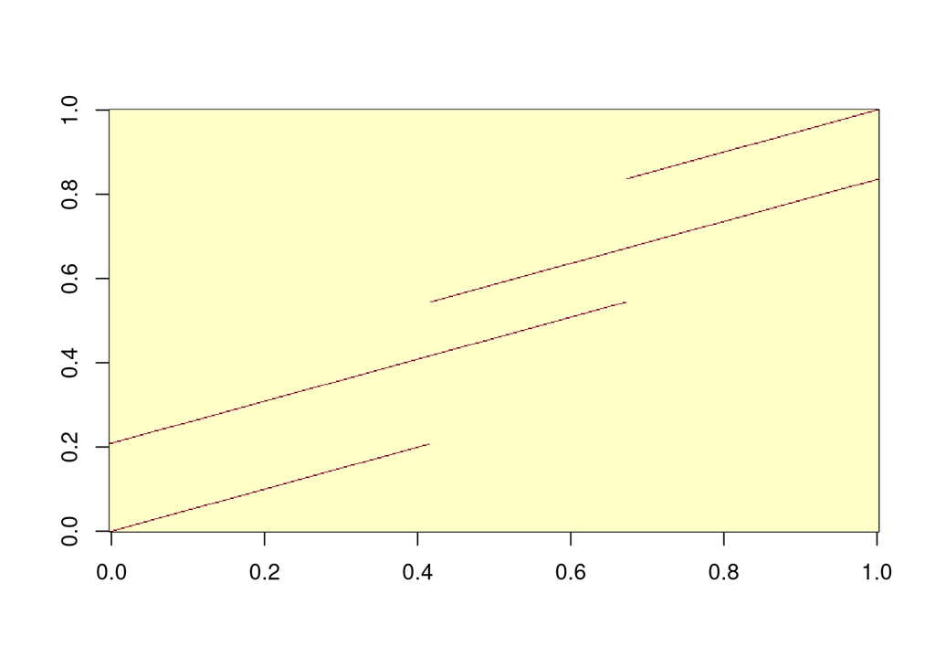

```r
# Run analysis including subject contrast?
include_id_contrast = TRUE

# Get id contrast matrix
id_contrast <- get_id_contrast(id_col = dat %>% select(participant) %>% rename(id=participant))

# Display matrix
image(t(id_contrast))
```

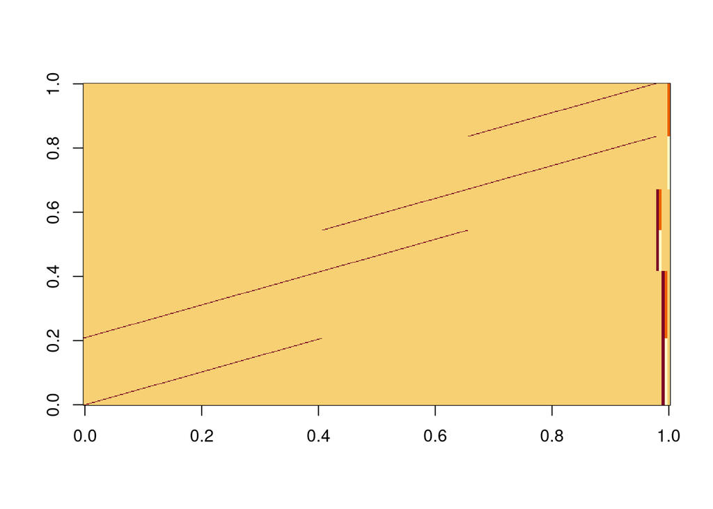

```r
# Get contrast
X_a <- get_contrast_A(dat, val_long = contrast_value_long, val_short = contrast_value_short)
# Full contrast image
image(t(X_a))
```

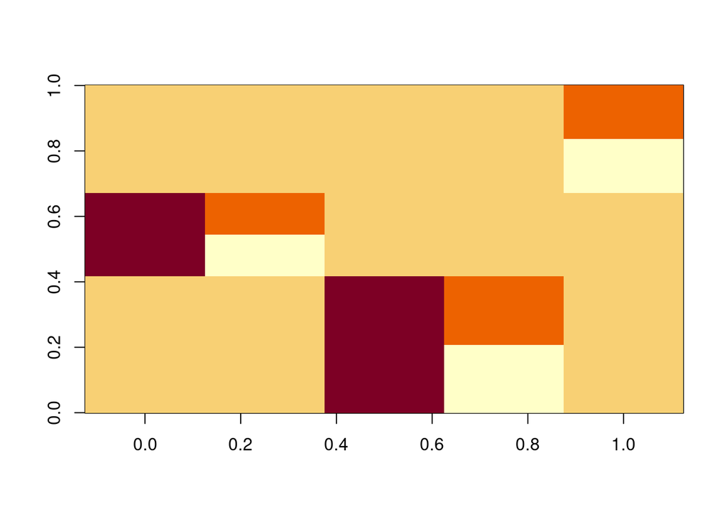

```r
# Only manipulation contrast
make_condition_contrast_image(X_a)
```

#### nWayAov

```r
# Get gMap
gMap <- get_gMap(X_a)
# Run nWayAOV
out <- get_bf_samp(y = dat$value, x = X_a, gMap = gMap, rscale = r,
                   no_iter = no_iter, filter_iter = filter_iter)
# Get simple BF
bf_out_a <- out[[1]]
# Get sampled data
samp_out_a <- out[[2]]
```

##### Check estimated values

```r
checkmeans_a <- with(dat, tapply(value, cond_code, mean))
pm.effest.a <- colMeans(samp_out_a)
```

Contrast A :

- mu: pay-off intercept
- beta 1: muller-lyer intercept
- beta 2: muller-lyer (long-short)
- beta 3: base-rate intercept
- beta 4: base-rate (long-short)
- beta 5: pay-off (long-short)

```r
# get bias manipulation beta names
beta_names <- paste0('beta_', grep('x[0-9]{1}$', colnames(X_a)))

# Rename columns
sampled_means_a <-
  set_names(pm.effest.a[c('mu', beta_names)], c('mu', 'ml_int', 'ml_bd', 'br_int', 'br_bd', 'po_bd'))

# Compare means
checkmeans_a
```

```
##     balo     bash     mulo     mush     palo     pash
## 392.3485 406.5357 392.3019 402.1786 388.7049 409.9646
```

```r
c(
  'balo' = sampled_means_a['mu'] + sampled_means_a['br_int'] - .5 * sampled_means_a['br_bd'],
  'bash' = sampled_means_a['mu'] + sampled_means_a['br_int'] + .5 * sampled_means_a['br_bd'],

  'mulo' = sampled_means_a['mu'] + sampled_means_a['ml_int'] - .5 * sampled_means_a['ml_bd'],
  'mush' = sampled_means_a['mu'] + sampled_means_a['ml_int'] + .5 * sampled_means_a['ml_bd'],

  'palo' = sampled_means_a['mu'] - .5 * sampled_means_a['po_bd'],
  'pash' = sampled_means_a['mu'] + .5 * sampled_means_a['po_bd']

)
```

```
##  balo.mu  bash.mu  mulo.mu  mush.mu  palo.mu  pash.mu
## 392.4440 406.4158 392.5967 402.0800 388.7608 409.8220
```

### Contrast B: all within cond effects are the same size.

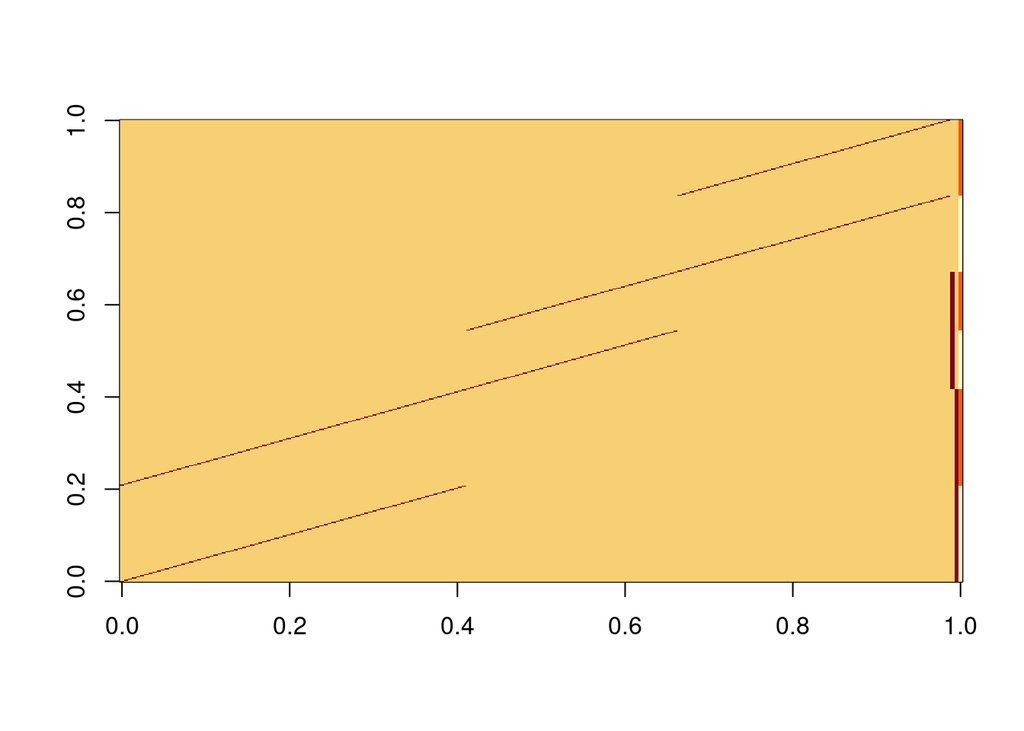

```r
# Get contrast
X_b <- get_contrast_B(dat, val_long = contrast_value_long, val_short = contrast_value_short)
# Full contrast image
image(t(X_b))
```

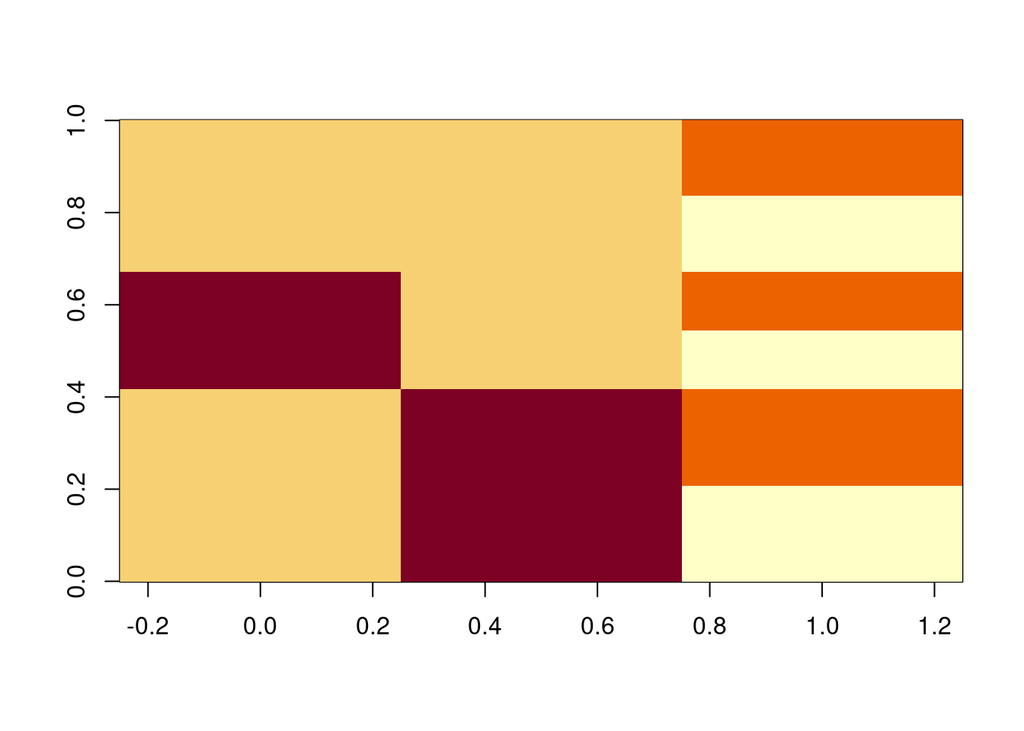

```r
# Only manipulation contrast
make_condition_contrast_image(X_b)
```

#### nWayAov

```r
# Get gMap
gMap <- get_gMap(X_b)
# Run nWayAOV
out <- get_bf_samp(y = dat$value, x = X_b, gMap = gMap, rscale = r,
                   no_iter = no_iter, filter_iter = filter_iter)
# Get simple BF
bf_out_b <- out[[1]]
# Get sampled data
samp_out_b <- out[[2]]
```

##### Check estimated values

```r
checkmeans_b <- with(dat, tapply(value, cond_code, mean))
pm.effest.b <- colMeans(samp_out_b)
```

Contrasts:

- mu: payoff intercept
- beta 1: muller-lyer intercept
- beta 2: base-rate intercept
- beta 3: (mulo,balo,palo) - (mush,bash,pash)

```r
# get bias manipulation beta names
beta_names <- paste0('beta_', grep('x[0-9]{1}$', colnames(X_b)))

# Rename columns
sampled_means_b <-
  set_names(pm.effest.b[c('mu', beta_names)], c('mu', 'ml_int', 'br_int', 'mlbrpo_bd'))

# Compare means
checkmeans_a
```

```
##     balo     bash     mulo     mush     palo     pash
## 392.3485 406.5357 392.3019 402.1786 388.7049 409.9646
```

```r
c(

  'balo' = sampled_means_b['mu'] + sampled_means_b['br_int'] - .5 * sampled_means_b['mlbrpo_bd'],
  'bash' = sampled_means_b['mu'] + sampled_means_b['br_int'] + .5 * sampled_means_b['mlbrpo_bd'],

  'mulo' = sampled_means_b['mu'] + sampled_means_b['ml_int'] - .5 * sampled_means_b['mlbrpo_bd'],
  'mush' = sampled_means_b['mu'] + sampled_means_b['ml_int'] + .5 * sampled_means_b['mlbrpo_bd'],

  'palo' = sampled_means_b['mu']  - .5 * sampled_means_b['mlbrpo_bd'],
  'palo' = sampled_means_b['mu']  + .5 * sampled_means_b['mlbrpo_bd']

)
```

```
##  balo.mu  bash.mu  mulo.mu  mush.mu  palo.mu  palo.mu
## 391.7916 407.1120 389.6824 405.0028 391.6171 406.9375
```

### Contrast C: Bias direction effect is equal in Muller-Lyer and Baserate, different in Payoff [(ML == BR) != PO]

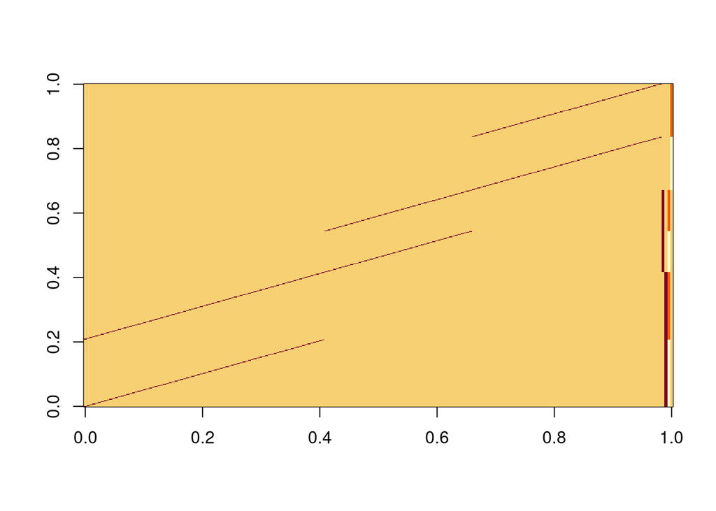

```r
# Get contrast
X_c <- get_contrast_C(dat, val_long = contrast_value_long, val_short = contrast_value_short)
# Full contrast image
image(t(X_c))
```

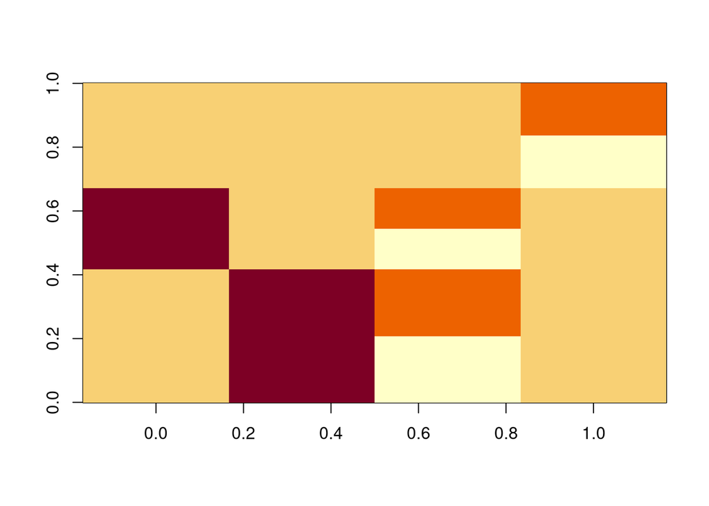

```r
# Only manipulation contrast
make_condition_contrast_image(X_c)
```

#### nWayAov

```r
# Get gMap
gMap <- get_gMap(X_c)
# Run nWayAOV
out <- get_bf_samp(y = dat$value, x = X_c, gMap = gMap, rscale = r,
                   no_iter = no_iter, filter_iter = filter_iter)
# Get simple BF
bf_out_c <- out[[1]]
# Get sampled data
samp_out_c <- out[[2]]
```

##### Check estimated values

```r
checkmeans_c <- checkmeans_a
pm.effest.c <- colMeans(samp_out_c)
```

Contrasts:

- mu: payoff intercept
- beta 1: muller-lyer intercept
- beta 2: base-rate intercept
- beta 3: (mulo, balo) - (mush, bash)
- beta 4: payoff (long-short)

```r
# get bias manipulation beta names
beta_names <- paste0('beta_', grep('x[0-9]{1}$', colnames(X_c)))
# Rename columns
sampled_means_c <-
  set_names(pm.effest.c[c('mu', beta_names)], c('mu', 'ml_int', 'br_int', 'mlbr_bd', 'po_bd'))

# Compare means
checkmeans_c
```

```
##     balo     bash     mulo     mush     palo     pash
## 392.3485 406.5357 392.3019 402.1786 388.7049 409.9646
```

```r
c(

  'balo' = sampled_means_c['mu'] +  sampled_means_c['br_int'] - .5 * sampled_means_c['mlbr_bd'],
  'bash' = sampled_means_c['mu'] +  sampled_means_c['br_int'] + .5 * sampled_means_c['mlbr_bd'],

  'mulo' = sampled_means_c['mu'] + sampled_means_c['ml_int']  - .5 * sampled_means_c['mlbr_bd'],
  'mush' = sampled_means_c['mu'] + sampled_means_c['ml_int']  + .5 * sampled_means_c['mlbr_bd'],

  'palo' = sampled_means_c['mu'] - .5 * sampled_means_c['po_bd'],
  'palo' = sampled_means_c['mu'] + .5 * sampled_means_c['po_bd']

)
```

```
##  balo.mu  bash.mu  mulo.mu  mush.mu  palo.mu  palo.mu
## 393.2324 405.6376 391.1208 403.5259 388.7401 409.7796
```

### Contrast D: Bias direction effect is equal in Muller-Lyer and Payoff, different in Base rate [(ML == PO) != BR]

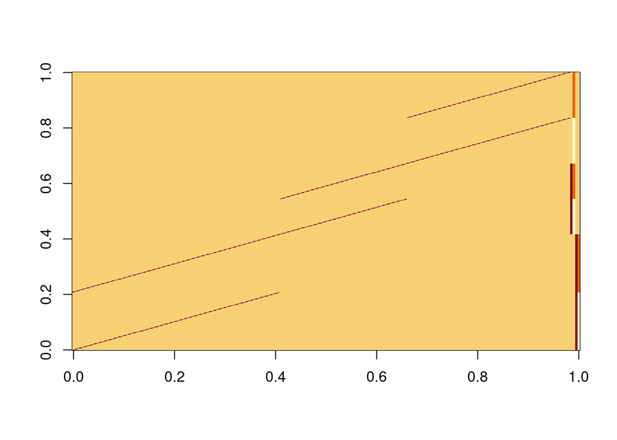

```r
# Get contrast
X_d <- get_contrast_D(dat, val_long = contrast_value_long, val_short = contrast_value_short)
# Full contrast image
image(t(X_d))
```

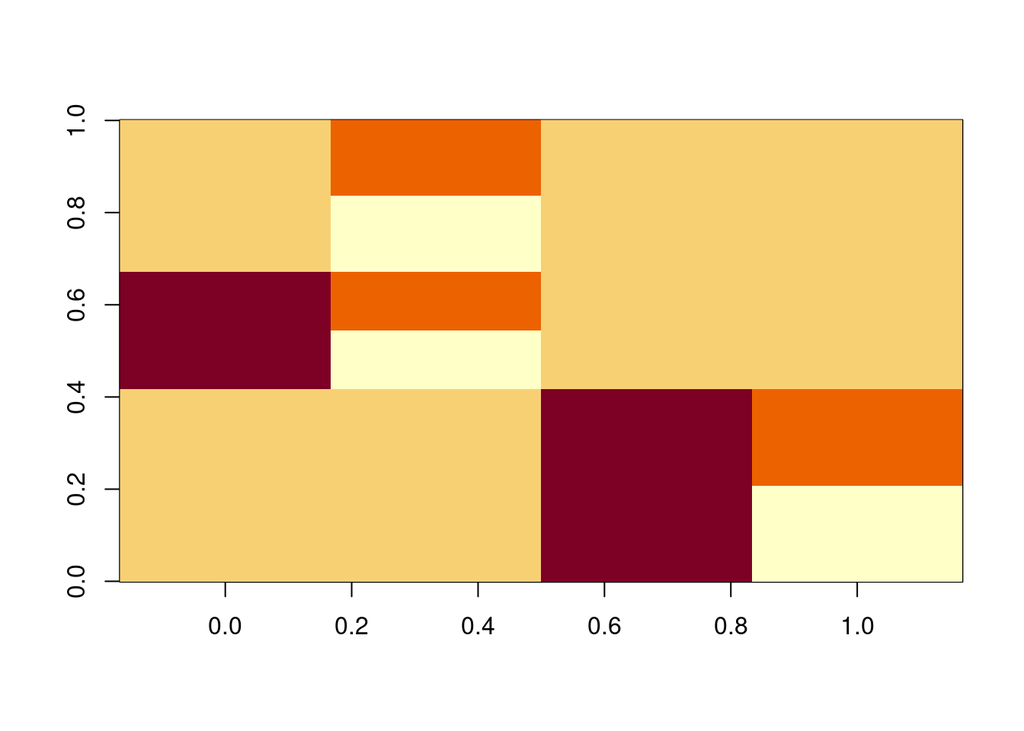

```r
# Only manipulation contrast
make_condition_contrast_image(X_d)
```

#### nWayAov

```r
# Get gMap
gMap <- get_gMap(X_d)
# Run nWayAOV
out <- get_bf_samp(y = dat$value, x = X_d, gMap = gMap, rscale = r,
                   no_iter = no_iter, filter_iter = filter_iter)
# Get simple BF
bf_out_d <- out[[1]]
# Get sampled data
samp_out_d <- out[[2]]
```

##### Check estimated values

```r
checkmeans_d <- checkmeans_a
pm.effest.d <- colMeans(samp_out_d)
```

Contrasts:

- mu: payoff intercept
- beta 1: muller-lyer intercept
- beta 2: (mulo, palo) - (mush, pash)
- beta 3: base-rate intercept
- beta 4: base-rate (long-short)

```r
# get bias manipulation beta names
beta_names <- paste0('beta_', grep('x[0-9]{1}$', colnames(X_d)))

# Rename columns
sampled_means_d <-
  set_names(pm.effest.d[c('mu', beta_names)], c('mu', 'ml_int', 'mlpo_bd', 'br_int', 'br_bd'))

# Compare means
checkmeans_d
```

```
##     balo     bash     mulo     mush     palo     pash
## 392.3485 406.5357 392.3019 402.1786 388.7049 409.9646
```

```r
c(

  'balo' = sampled_means_d['mu'] + sampled_means_d['br_int'] - .5 * sampled_means_d['br_bd'],
  'bash' = sampled_means_d['mu'] + sampled_means_d['br_int'] + .5 * sampled_means_d['br_bd'],

  'mulo' = sampled_means_d['mu'] + sampled_means_d['ml_int'] - .5 * sampled_means_d['mlpo_bd'],
  'mush' = sampled_means_d['mu'] + sampled_means_d['ml_int'] + .5 * sampled_means_d['mlpo_bd'],

  'palo' = sampled_means_d['mu']  - .5 * sampled_means_d['mlpo_bd'],
  'palo' = sampled_means_d['mu']  + .5 * sampled_means_d['mlpo_bd']

)
```

```
##  balo.mu  bash.mu  mulo.mu  mush.mu  palo.mu  palo.mu
## 392.4148 406.4274 389.2738 405.4110 391.1924 407.3296
```

### Contrast E: Bias direction effect in the Muller-Lyer condition, no effect in base rate and payoff [(mulo > mush) & (balo == bash) & (palo = pash)]

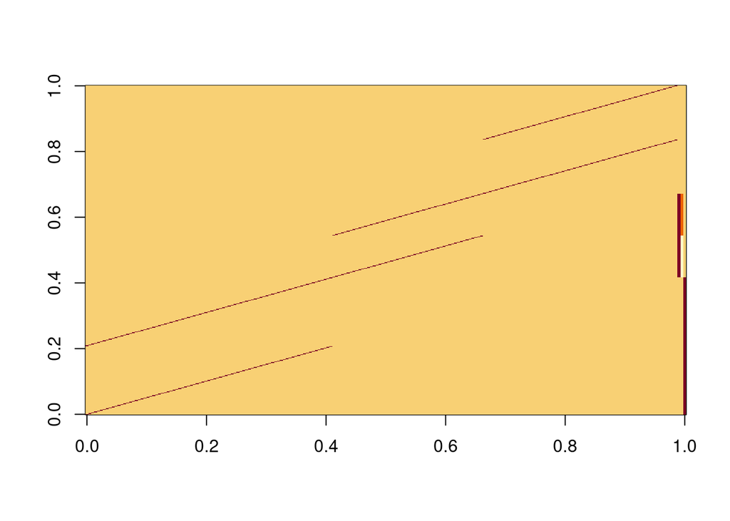

```r
# Get contrast
X_e <- get_contrast_E(dat, val_long = contrast_value_long, val_short = contrast_value_short)
# Full contrast image
image(t(X_e))
```

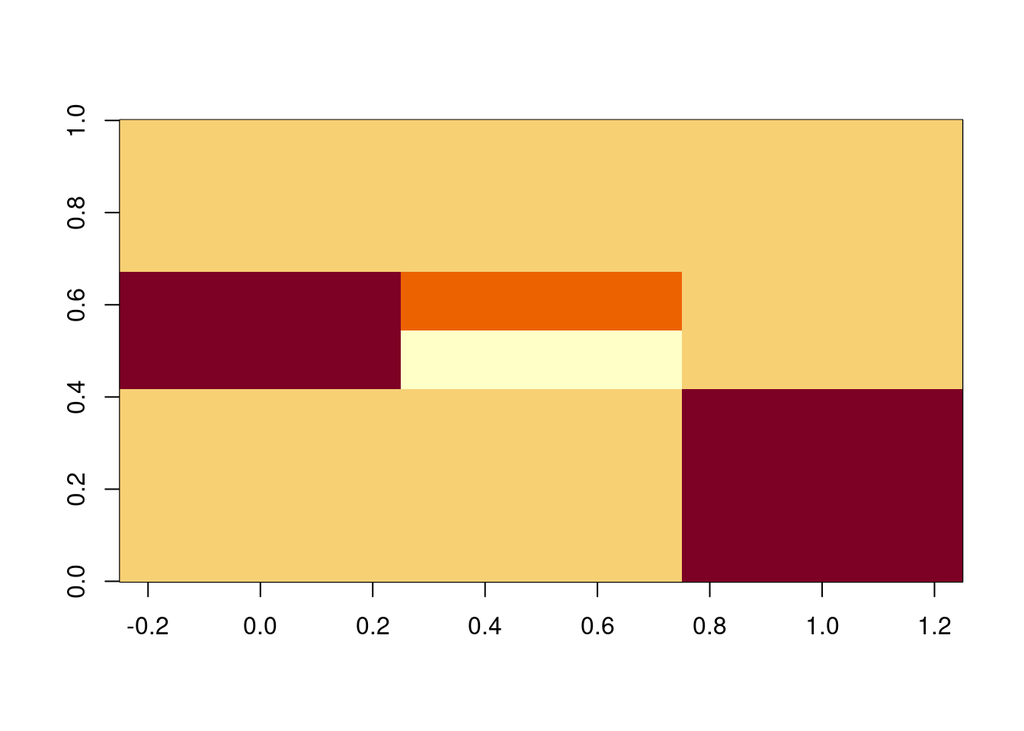

```r
# Only manipulation contrast
make_condition_contrast_image(X_e)
```

#### nWayAov

```r
# Get gMap
gMap <- get_gMap(X_e)
# Run nWayAOV
out <- get_bf_samp(y = dat$value, x = X_e, gMap = gMap, rscale = r,
                   no_iter = no_iter, filter_iter = filter_iter)
# Get simple BF
bf_out_e <- out[[1]]
# Get sampled data
samp_out_e <- out[[2]]
```

#### Check estimated values

```r
pm.effest.e <- colMeans(samp_out_e)
```

Contrasts:

- mu: payoff intercept
- beta 1: muller-lyer intercept
- beta 2: muller-lyer (long-short)
- beta 3: base-rate intercept

```r
# get bias manipulation beta names
beta_names <- paste0('beta_', grep('x[0-9]{1}$', colnames(X_e)))

# Rename columns
sampled_means_e <-
  set_names(pm.effest.e[c('mu', beta_names)], c('mu', 'ml_int', 'ml_bd', 'br_int'))
c(
  'ba' = mean(checkmeans_a['balo'], checkmeans_a['bash']),
  'pa' =mean(checkmeans_a['palo'], checkmeans_a['pash']),
  checkmeans_a[c('mulo', 'mush')]
)
```

```
##       ba       pa     mulo     mush
## 392.3485 388.7049 392.3019 402.1786
```

```r
c(

  'ba' = sampled_means_e['mu'] + sampled_means_e['br_int'],
  'pa' = sampled_means_e['mu'],

  'mulo' = sampled_means_e['mu'] + sampled_means_e['ml_int'] - .5 * sampled_means_e['ml_bd'],
  'mush' = sampled_means_e['mu'] + sampled_means_e['ml_int'] + .5 * sampled_means_e['ml_bd']


)
```

```
##    ba.mu    pa.mu  mulo.mu  mush.mu
## 399.4491 399.2743 392.7104 401.9217
```

### Contrast F: No effect in any bias source [(mulo = mush) != (balo == bash) != (palo = pash)]

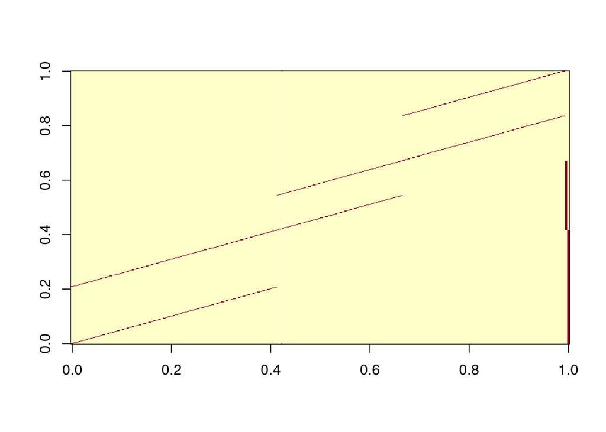

```r
# Get contrast
X_f <- get_contrast_F(dat)
# Full contrast image
image(t(X_f))
```

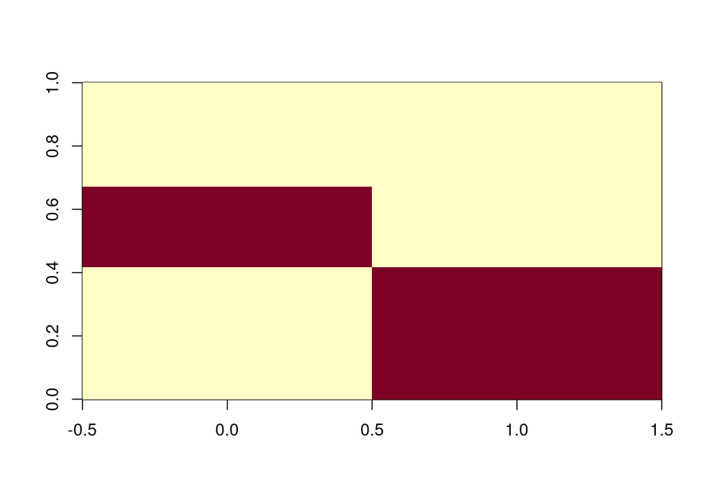

```r
# Only manipulation contrast
make_condition_contrast_image(X_f)
```

#### nWayAov

```r
# Get gMap
gMap <- get_gMap(X_f)
# Run nWayAOV
out <- get_bf_samp(y = dat$value, x = X_f, gMap = gMap, rscale = r,
                   no_iter = no_iter, filter_iter = filter_iter)
# Get simple BF
bf_out_f <- out[[1]]
# Get sampled data
samp_out_f <- out[[2]]
```

#### Check estimated values

Contrasts:

- mu: payoff intercept
- beta 1: muller-lyer intercept
- beta 2: base-rate intercept

```r
checkmeans_f <- with(dat, tapply(value, bias_source, mean))
pm.effest.f <- colMeans(samp_out_f)
```

```r
# get bias manipulation beta names
beta_names <- paste0('beta_', grep('x[0-9]{1}$', colnames(X_f)))

# Rename columns
sampled_means_f <-
  set_names(pm.effest.f[c('mu', beta_names)], c('mu', 'ml_int', 'br_int'))


# Compare means
checkmeans_f
```

```
##   baserate mullerlyer     payoff
##   399.4421   397.2403   399.3348
```

```r
c(
  'ba' = sampled_means_f['mu'] + sampled_means_f['br_int'],
  'ml' = sampled_means_f['mu'] + sampled_means_f['ml_int'],
  'pa' = sampled_means_f['mu']
)
```

```
##    ba.mu    ml.mu    pa.mu
## 399.4325 397.3072 399.2545
```

### Contrast G: Bias direction effect in base rate and Muller-Lyer, no effect in payoff [(mulo > mush) > (balo > bash) & (palo = pash)]

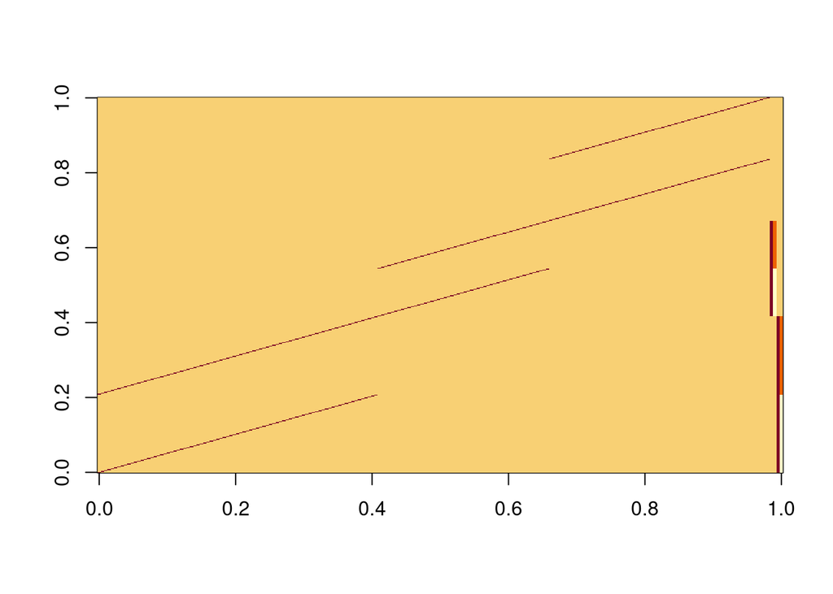

```r
# Get contrast
X_g <- get_contrast_G(dat, val_long = contrast_value_long, val_short = contrast_value_short)
# Full contrast image
image(t(X_g))
```

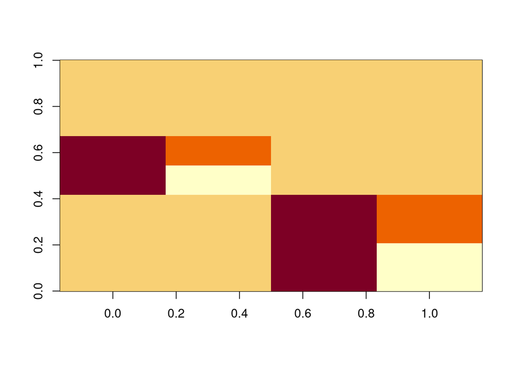

```r
# Only manipulation contrast
make_condition_contrast_image(X_g)
```

#### nWayAov

```r
# Get gMap
gMap <- get_gMap(X_g)
# Run nWayAOV
out <- get_bf_samp(y = dat$value, x = X_g, gMap = gMap, rscale = r,
                   no_iter = no_iter, filter_iter = filter_iter)
# Get simple BF
bf_out_g <- out[[1]]
# Get sampled data
samp_out_g <- out[[2]]
```

#### Check estimated values

```r
pm.effest.g <- colMeans(samp_out_g)
```

Contrasts:

- mu: payoff intercept
- beta 1: muller-lyer intercept
- beta 2: muller-lyer (long-short)
- beta 3: base-rate intercept
- beta 4: base-rate (long-short)

```r
# get bias manipulation beta names
beta_names <- paste0('beta_', grep('x[0-9]{1}$', colnames(X_g)))

# Rename columns
sampled_means_g <-
  set_names(pm.effest.g[c('mu', beta_names)], c('mu', 'ml_int', 'ml_bd', 'br_int', 'br_bd'))
```

```r
c(
  checkmeans_a['balo'],
  checkmeans_a['bash'],
  checkmeans_a[c('mulo', 'mush')],
  'pa'=mean(checkmeans_a['palo'], checkmeans_a['pash'])
)
```

```
##     balo     bash     mulo     mush       pa
## 392.3485 406.5357 392.3019 402.1786 388.7049
```

```r
c(
  'balo' = sampled_means_g['mu'] + sampled_means_g['br_int'] - .5 * sampled_means_g['br_bd'],
  'bash' = sampled_means_g['mu'] + sampled_means_g['br_int'] + .5 * sampled_means_g['br_bd'],

  'mulo' = sampled_means_g['mu'] + sampled_means_g['ml_int'] - .5 * sampled_means_g['ml_bd'],
  'mulo' = sampled_means_g['mu'] + sampled_means_g['ml_int'] + .5 * sampled_means_g['ml_bd'],

  'pa' = sampled_means_g['mu']
)
```

```
##  balo.mu  bash.mu  mulo.mu  mulo.mu    pa.mu
## 392.5064 406.3931 392.6632 401.9563 399.2660
```

### Contrast H: Bias direction effect in Payoff and Muller-Lyer, no effect in base rate [(mulo > mush) > (palo > pash) & (balo = bash)]

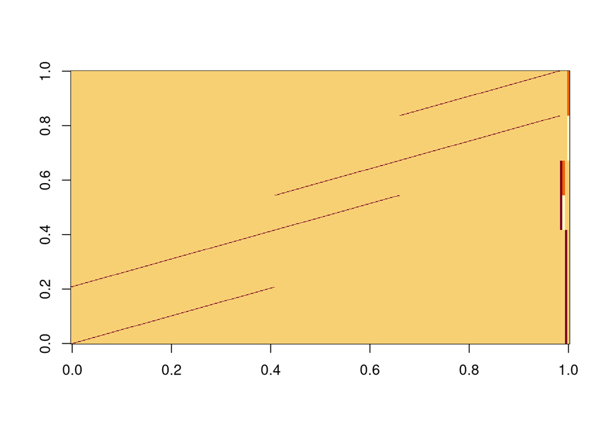

```r
# Get contrast
X_h <- get_contrast_H(dat, val_long = contrast_value_long, val_short = contrast_value_short)
# Full contrast image
image(t(X_h))
```

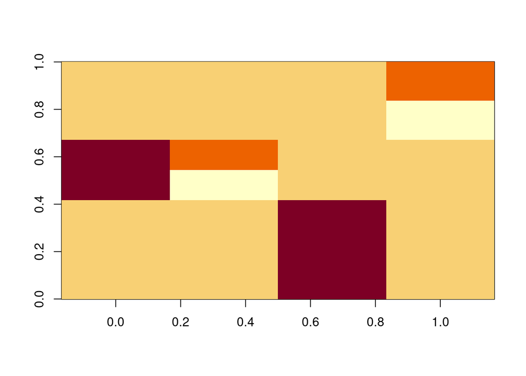

```r
# Only manipulation contrast
make_condition_contrast_image(X_h)
```

#### nWayAov

```r
# Get gMap
gMap <- get_gMap(X_h)
# Run nWayAOV
out <- get_bf_samp(y = dat$value, x = X_h, gMap = gMap, rscale = r,
                   no_iter = no_iter, filter_iter = filter_iter)
# Get simple BF
bf_out_h <- out[[1]]
# Get sampled data
samp_out_h <- out[[2]]
```

#### Check estimated values

```r
pm.effest.h <- colMeans(samp_out_h)
```

Contrasts:

```r
# get bias manipulation beta names
beta_names <- paste0('beta_', grep('x[0-9]{1}$', colnames(X_h)))

# Rename columns
sampled_means_h <-
  set_names(pm.effest.h[c('mu', beta_names)], c('mu', 'ml_int', 'ml_bd', 'br_int', 'po_bd'))
```

```r
c(
  checkmeans_a['palo'],
  checkmeans_a['pash'],
  checkmeans_a[c('mulo', 'mush')],
  'ba' = mean(checkmeans_a['balo'], checkmeans_a['bash'])
)
```

```
##     palo     pash     mulo     mush       ba
## 388.7049 409.9646 392.3019 402.1786 392.3485
```

```r
c(

  'palo' = sampled_means_h['mu'] - .5 * sampled_means_h['po_bd'],
  'pash' = sampled_means_h['mu'] + .5 * sampled_means_h['po_bd'],

  'mulo' = sampled_means_h['mu'] + sampled_means_h['ml_int'] - .5 * sampled_means_h['ml_bd'],
  'mush' = sampled_means_h['mu'] + sampled_means_h['ml_int'] + .5 * sampled_means_h['ml_bd'],

  'ba' = sampled_means_h['mu']

)
```

```
##  palo.mu  pash.mu  mulo.mu  mush.mu    ba.mu
## 388.7852 409.7977 392.5957 402.0018 399.2914
```

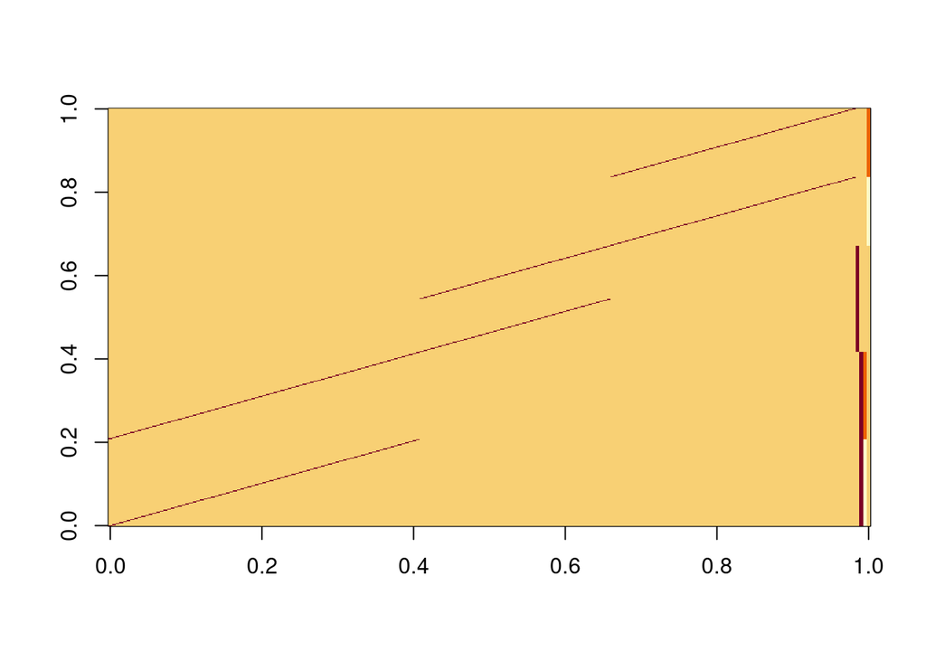

```r
# Get contrast
X_i <- get_contrast_I(dat, val_long = contrast_value_long, val_short = contrast_value_short)
# Full contrast image
image(t(X_i))
```

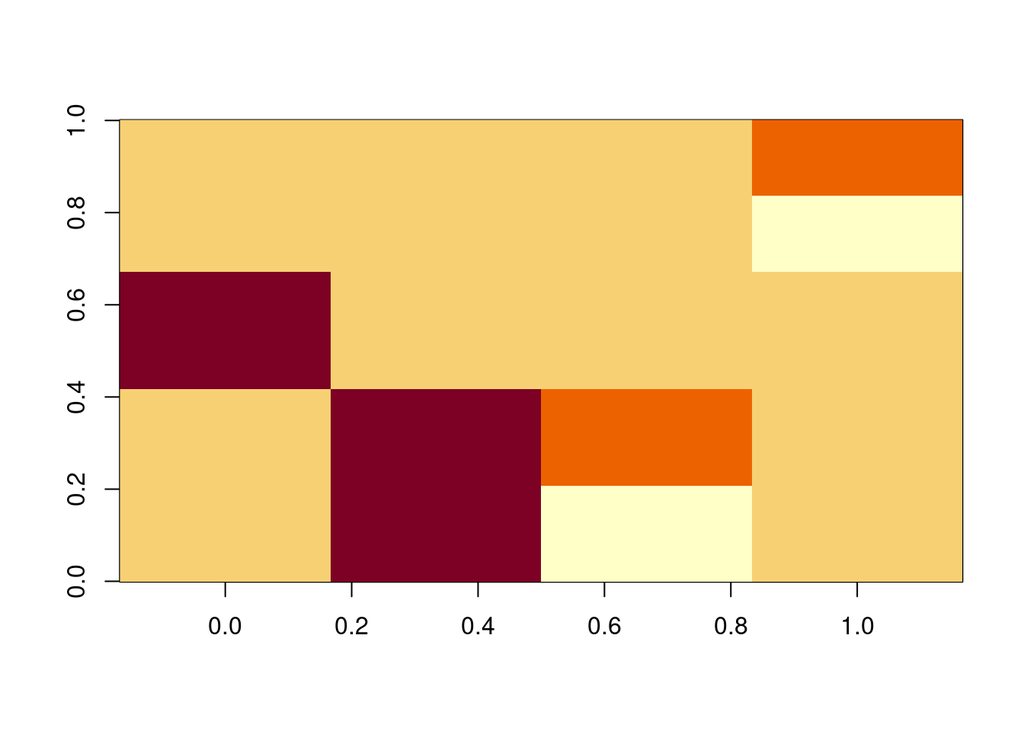

```r
# Only manipulation contrast
make_condition_contrast_image(X_i)
```

#### nWayAov

```r
# Get gMap
gMap <- get_gMap(X_i)
# Run nWayAOV
out <- get_bf_samp(y = dat$value, x = X_i, gMap = gMap, rscale = r,
                   no_iter = no_iter, filter_iter = filter_iter)
# Get simple BF
bf_out_i <- out[[1]]
# Get sampled data
samp_out_i <- out[[2]]
```

#### Check estimated values

```r
pm.effest.i <- colMeans(samp_out_i)
```

Contrasts:

- mu: payoff intercept
- beta 1: muller-lyer intercept
- beta 2: base-rate intercept
- beta 3: base-rate (long-short)
- beta 4: payoff (long-short)

```r
# get bias manipulation beta names
beta_names <- paste0('beta_', grep('x[0-9]{1}$', colnames(X_i)))

# Rename columns
sampled_means_i <-
  set_names(pm.effest.i[c('mu', beta_names)], c('mu', 'ml_int', 'br_int', 'br_bd', 'po_bd'))
```

```r
c(mu = mean(checkmeans_a[c('mulo', 'mush')]), checkmeans_a[c('palo', 'pash', 'balo', 'bash')])
```

```
##       mu     palo     pash     balo     bash
## 397.2403 388.7049 409.9646 392.3485 406.5357
```

```r
c(
  'mulo' = sampled_means_i['mu'] + sampled_means_i['ml_int'],

  'palo' = sampled_means_i['mu'] - .5 * sampled_means_i['po_bd'],
  'pash' = sampled_means_i['mu'] + .5 * sampled_means_i['po_bd'],

  'balo' = sampled_means_i['mu'] + sampled_means_i['br_int'] - .5 * sampled_means_i['br_bd'],
  'bash' = sampled_means_i['mu'] + sampled_means_i['br_int'] + .5 * sampled_means_i['br_bd']

)
```

```
##  mulo.mu  palo.mu  pash.mu  balo.mu  bash.mu
## 397.3267 388.7445 409.8149 392.4406 406.4363
```

### Contrast J: Bias direction effect in the payoff condition, no effect in base rate and muller lyer [(palo > pash) & (balo == bash) & (mulo = mush)]

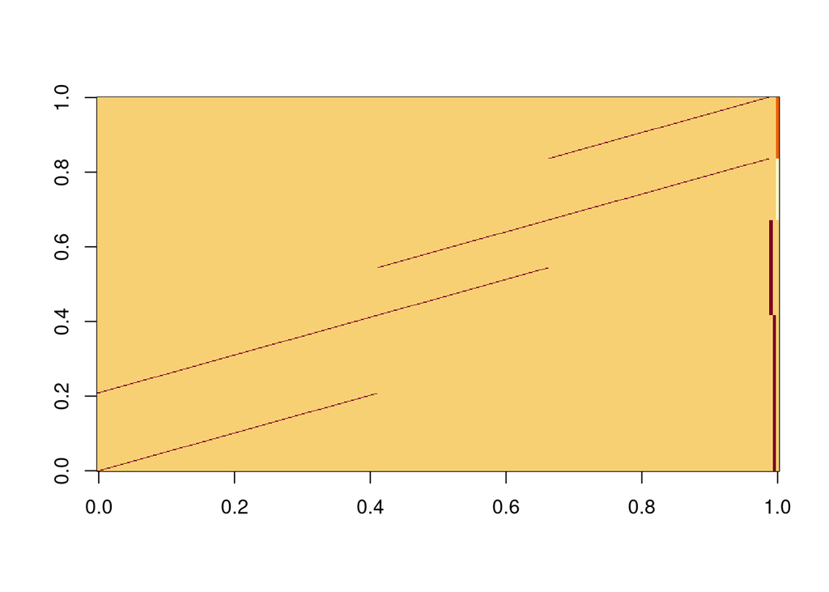

```r
# Get contrast
X_j <- get_contrast_J(dat, val_long = contrast_value_long, val_short = contrast_value_short)
# Full contrast image
image(t(X_j))
```

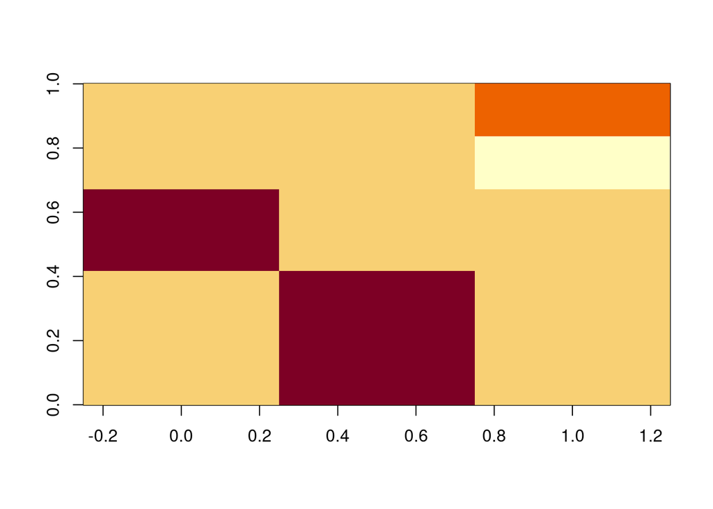

```r
# Only manipulation contrast
make_condition_contrast_image(X_j)
```

#### nWayAov

```r
# Get gMap
gMap <- get_gMap(X_j)
# Run nWayAOV
out <- get_bf_samp(y = dat$value, x = X_j, gMap = gMap, rscale = r,
                   no_iter = no_iter, filter_iter = filter_iter)
# Get simple BF
bf_out_j <- out[[1]]
# Get sampled data
samp_out_j <- out[[2]]
```

#### Check estimated values

```r
pm.effest.j <- colMeans(samp_out_j)
```

Contrasts:

- mu: payoff intercept
- beta 1: muller-lyer intercept
- beta 2: base-rate intercept
- beta 3: payoff (long-short)

```r
# get bias manipulation beta names
beta_names <- paste0('beta_', grep('x[0-9]{1}$', colnames(X_j)))

# Rename columns
sampled_means_j <-
  set_names(pm.effest.j[c('mu', beta_names)], c('mu', 'ml_int', 'br_int', 'pa_bd'))
```

```r
c(
  'ba' = mean(checkmeans_a['balo'], checkmeans_a['bash']),
  'mu' = mean(checkmeans_a[c('mulo', 'mush')]),
  checkmeans_a['palo'],
  checkmeans_a['pash']
)
```

```
##       ba       mu     palo     pash
## 392.3485 397.2403 388.7049 409.9646
```

```r
c(

  'ba' = sampled_means_j['mu'] + sampled_means_j['br_int'],
  'mu' = sampled_means_j['mu'] + sampled_means_j['ml_int'],

  'palo' = sampled_means_j['mu'] - .5 * sampled_means_j['pa_bd'],
  'pash' = sampled_means_j['mu'] + .5 * sampled_means_j['pa_bd']


)
```

```
##    ba.mu    mu.mu  palo.mu  pash.mu
## 399.4330 397.3126 388.7464 409.7898
```

### Contrast K: Bias direction effect in the base-rate condition, no effect in payoff and muller lyer [(balo > bash) & (palo == pash) & (mulo = mush)]

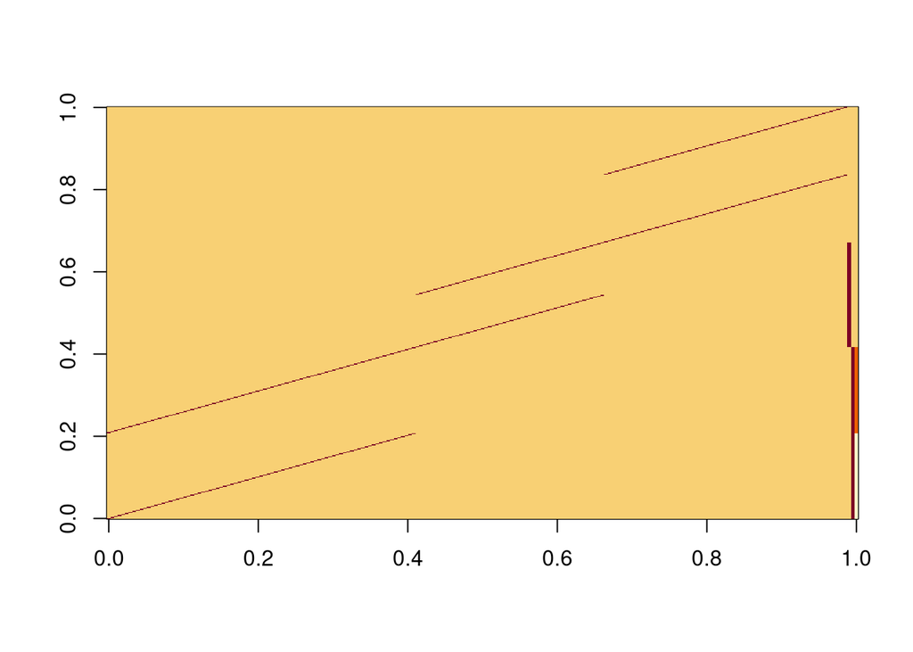

```r
# Get contrast
X_k <- get_contrast_K(dat, val_long = contrast_value_long, val_short = contrast_value_short)
# Full contrast image
image(t(X_k))
```

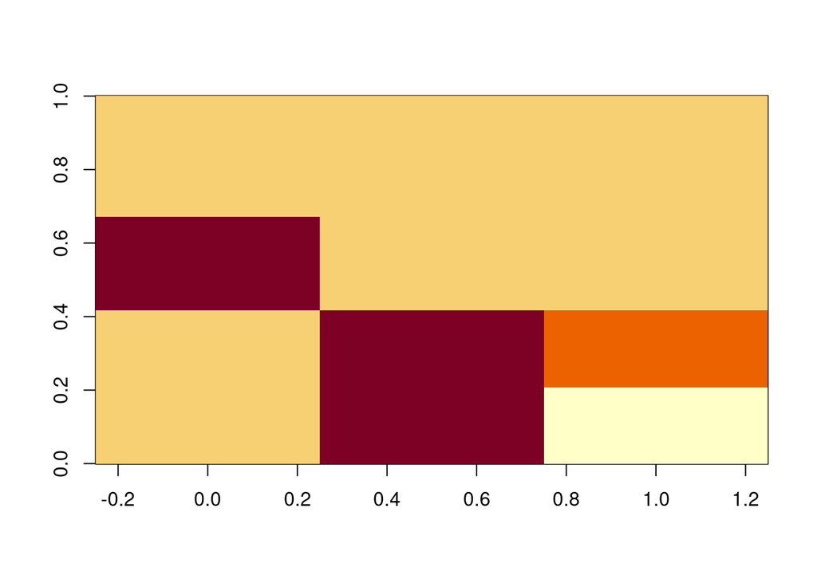

```r
# Only manipulation contrast
make_condition_contrast_image(X_k)
```

#### nWayAov

```r
# Get gMap
gMap <- get_gMap(X_k)
# Run nWayAOV
out <- get_bf_samp(y = dat$value, x = X_k, gMap = gMap, rscale = r,
                   no_iter = no_iter, filter_iter = filter_iter)
# Get simple BF
bf_out_k <- out[[1]]
# Get sampled data
samp_out_k <- out[[2]]
```

#### Check estimated values

```r
pm.effest.k <- colMeans(samp_out_k)
```

Contrasts:

```r
# get bias manipulation beta names
beta_names <- paste0('beta_', grep('x[0-9]{1}$', colnames(X_k)))

# Rename columns
sampled_means_k <-
  set_names(pm.effest.k[c('mu', beta_names)], c('mu', 'ml_int', 'br_int', 'ba_bd'))

c(
  'balo' = checkmeans_a['balo'],
  'bash' = checkmeans_a['bash'],
  'mu' = mean(checkmeans_a[c('mulo', 'mush')]),
  'pa' = mean(checkmeans_a['palo'], checkmeans_a['pash'])
)
```

```
## balo.balo bash.bash        mu        pa
##  392.3485  406.5357  397.2403  388.7049
```

```r
c(

  'balo' = sampled_means_k['mu'] + sampled_means_k['br_int'] - .5 * sampled_means_k['ba_bd'],
  'bash' = sampled_means_k['mu'] + sampled_means_k['br_int'] + .5 * sampled_means_k['ba_bd'],
  'mu' = sampled_means_k['mu'] + sampled_means_k['ml_int'],
  'palo' = sampled_means_k['mu']

)
```

```
##  balo.mu  bash.mu    mu.mu  palo.mu
## 392.4831 406.3839 397.3129 399.2732
```

### Contrast L: Bias direction effect is equal in Base rate and Payoff, different in Muller-Lyer [(BR == PO) != ML]

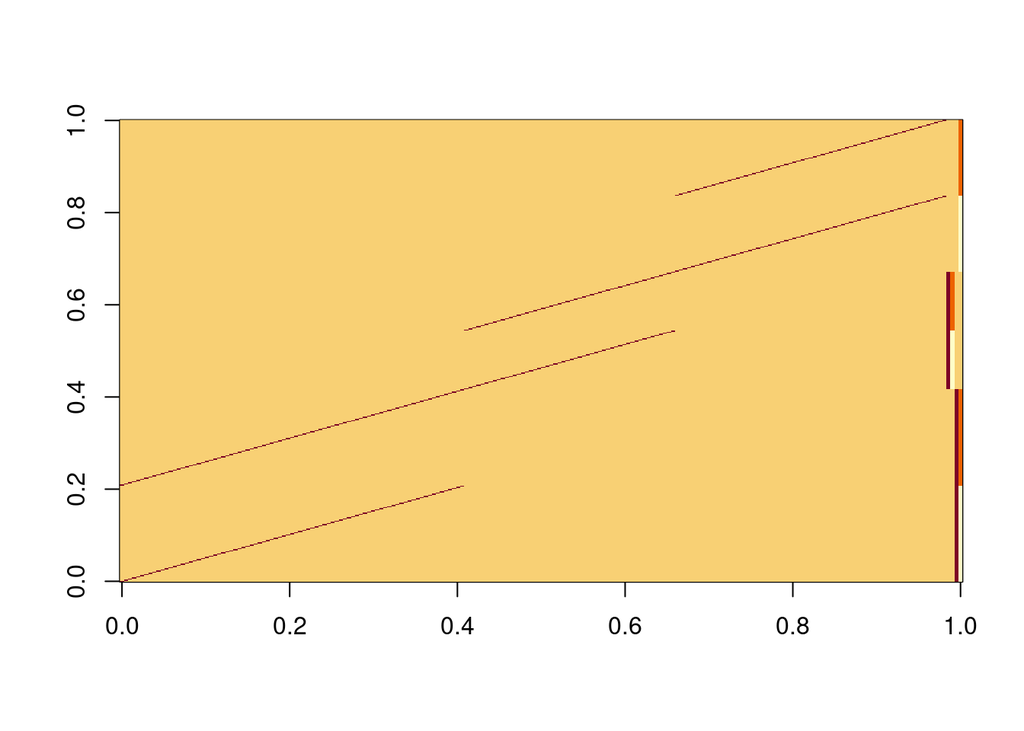

```r
# Get contrast
X_l <- get_contrast_L(dat, val_long = contrast_value_long, val_short = contrast_value_short)
# Full contrast image
image(t(X_l))
```

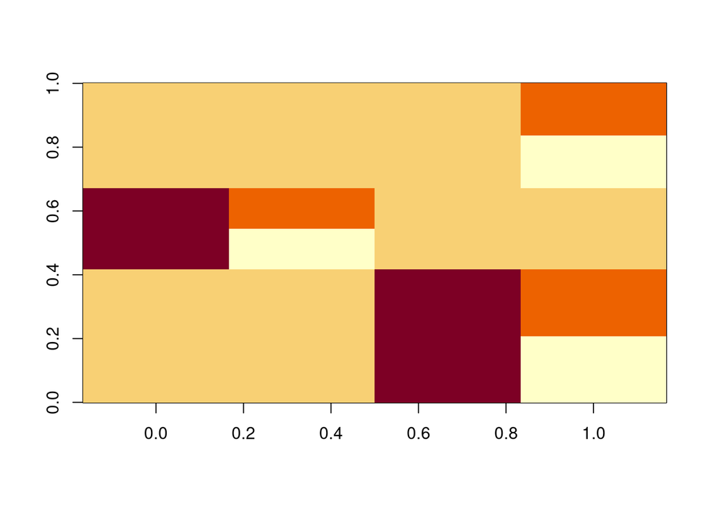

```r
# Only manipulation contrast
make_condition_contrast_image(X_l)
```

#### nWayAov

```r
# Get gMap
gMap <- get_gMap(X_l)
# Run nWayAOV
out <- get_bf_samp(y = dat$value, x = X_l, gMap = gMap, rscale = r,
                   no_iter = no_iter, filter_iter = filter_iter)
# Get simple BF
bf_out_l <- out[[1]]
# Get sampled data
samp_out_l <- out[[2]]
```

##### Check estimated values

```r
checkmeans_l <- checkmeans_a
pm.effest.l <- colMeans(samp_out_l)
```

Contrasts:

- mu: payoff intercept
- beta 1: muller-lyer intercept
- beta 2: muller-lyer (long-short)
- beta 3: base-rate intercept
- beta 4: (balo, palo) - (bash, pash)

```r
# get bias manipulation beta names
beta_names <- paste0('beta_', grep('x[0-9]{1}$', colnames(X_l)))

# Rename columns
sampled_means_l <-
  set_names(pm.effest.l[c('mu', beta_names)], c('mu', 'ml_int', 'ml_bd', 'br_int', 'brpo_bd'))

# Compare means
checkmeans_l
```

```
##     balo     bash     mulo     mush     palo     pash
## 392.3485 406.5357 392.3019 402.1786 388.7049 409.9646
```

```r
c(

  'balo' = sampled_means_l['mu'] + sampled_means_l['br_int'] - .5 * sampled_means_l['brpo_bd'],
  'bash' = sampled_means_l['mu'] + sampled_means_l['br_int'] + .5 * sampled_means_l['brpo_bd'],

  'mulo' = sampled_means_l['mu'] + sampled_means_l['ml_int'] - .5 * sampled_means_l['ml_bd'],
  'mush' = sampled_means_l['mu'] + sampled_means_l['ml_int'] + .5 * sampled_means_l['ml_bd'],

  'palo' = sampled_means_l['mu']  - .5 * sampled_means_l['brpo_bd'],
  'palo' = sampled_means_l['mu']  + .5 * sampled_means_l['brpo_bd']

)
```

```
##  balo.mu  bash.mu  mulo.mu  mush.mu  palo.mu  palo.mu
## 390.8314 408.0304 392.5771 402.0667 390.6805 407.8794
```

### Calculate ordinal BF

```r
# Unconstrained model
bf_uN <- bf_out_f$bf

# model A: effect on all conditions, no constrained across them
bf_A <- bf_out_a$bf
# model B: effect only in Payoff
bf_B <- bf_out_j$bf
# model C: effect only in Muller-Lyer
bf_C <- bf_out_e$bf
# model D: effect only in Base rate
bf_D <- bf_out_k$bf
# model E: effect in Payoff and Baserate, no effect in Muller-Lyer
bf_E <- bf_out_i$bf
# model F: effect in Payoff and Muller-Lyer, no effect in Baserate
bf_F <- bf_out_h$bf
# model G: effect in Muller-Lyer and Baserate, no effect in Payoff
bf_G <- bf_out_g$bf
```

## Make table with bf values

```r
bfs <-
  tribble(
    ~model, ~bf, ~model_label,
    'a', bf_A, 'BR & ML & PO',
    'b', bf_B, 'PO',
    'c', bf_C, 'ML',
    'd', bf_D, 'BR',
    'e', bf_E, 'BR & PO',
    'f', bf_F, 'ML & PO',
    'g', bf_G, 'BR & ML',
    'UN', bf_uN, 'BR & ML & PO (no effect in all manipulations)'
  )

bfs %>%
  write_csv(here(sprintf('data/ordinal_modeling/ord_models_%s_%s.csv', task_to_analyze, exp_data)))
```

## Print best models for quick check

```r
bfs_based <-
  bfs %>%
  filter(nchar(model) == 1) %>%
  mutate(baseline = bfs %>% filter(model == 'UN') %>% pull(bf),
         bf_over_baseline = bf-baseline) %>%
  arrange(desc(bf_over_baseline)) %>%
  filter(bf_over_baseline > 0)

bfs_based %>%
  mutate(bf_over_rest = exp(max(bf_over_baseline) - bf_over_baseline)) %>%
  filter(bf_over_rest < 100)
```

```
## # A tibble: 1 × 6
##   model    bf model_label  baseline bf_over_baseline bf_over_rest
##   <chr> <dbl> <chr>           <dbl>            <dbl>        <dbl>
## 1 a      108. BR & ML & PO    -12.1             120.            1
```